# Cleaning & Modeling | Home Credit Default Risk

10/30/2024

# Project Descriptions & Summaries

## Business Problem

Home Credit Group struggles to accurately assess the creditworthiness of clients with limited or no credit history, leading to missed opportunities and higher default rates. The goal is to improve financial inclusion by responsibly lending to underserved clients who are likely to repay.

## Analytic Problem

The task is to build a predictive model using demographic, transactional, and alternative data to assess credit risk more accurately for non-traditional borrowers. This model aims to reduce defaults and improve loan approvals, with success measured by AUC-ROC, precision, recall, and F1 score.

## Data Cleaning and Preparation Summary

**Exploration and Initial Cleaning:**

- Loaded and explored datasets, analyzing class imbalance and relationships between predictors and the TARGET variable.

**Handling Missing Data:**

- Removed columns with more than 50% missing values and applied median or mode imputation for essential features with moderate missing data.

**Outlier Handling:**

- Capped extreme outliers in income to the 99th percentile to minimize distortion.

**Feature Selection:**

- Removed low-correlation features and irrelevant columns to streamline the dataset.

**Final Checks:**

- Verified data integrity by checking for any remaining missing values or inconsistencies.

Some of the cleaning steps are in the “Cleaning Data” section below.

# Cleaning Data

## Task 1: Loading & exploring data

```r
library(caTools)

application_train <- read.csv("application_train.csv")
application_test <- read.csv("application_test.csv")
```

## Task 2: Analyzing the target variable and predictor relationships

```r
#Check the balance of the target variable.
table(application_train$TARGET)
```

```
##
##      0      1
## 282686  24825
```

```r
# Proportion of target variable
prop.table(table(application_train$TARGET))
```

```
##
##          0          1
## 0.91927118 0.08072882
```

```r
#Calculate the accuracy of a majority class predictor.
majority_class_accuracy <- max(table(application_train$TARGET)) / nrow(application_train)
majority_class_accuracy
```

```
## [1] 0.9192712
```

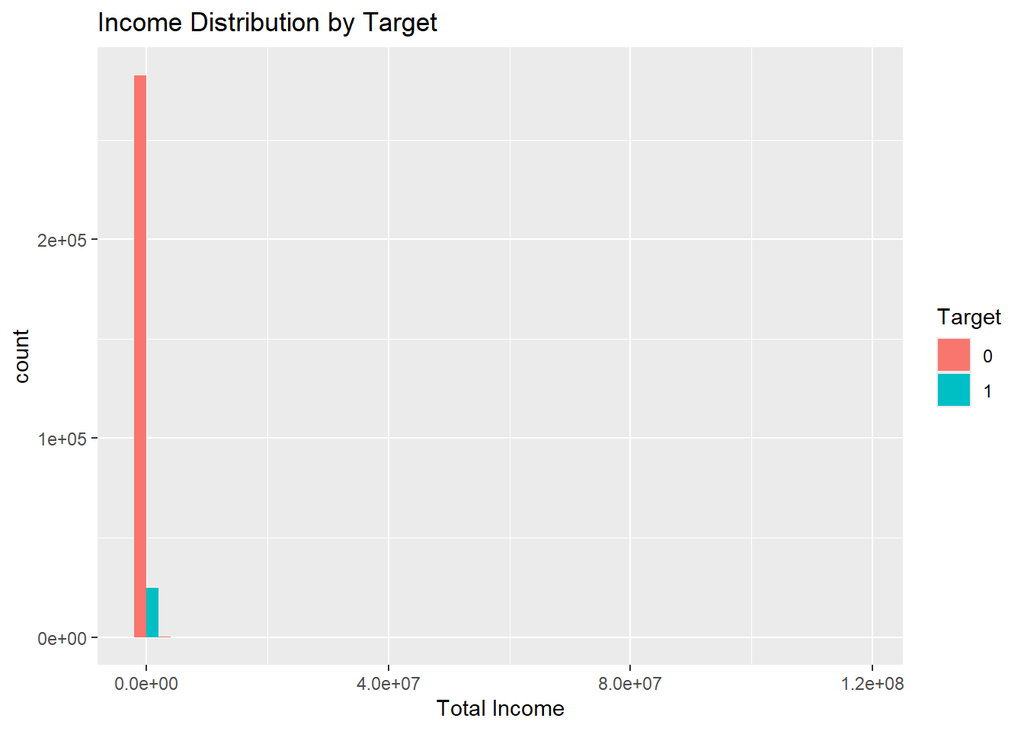

```r
#Visualizing Relationships
library(ggplot2)

ggplot(application_train, aes(x = AMT_INCOME_TOTAL, fill = as.factor(TARGET))) +
    geom_histogram(bins = 30, position = "dodge") +
    labs(title = "Income Distribution by Target", x = "Total Income", fill = "Target")
```

```r
#  Memory cleanup to remove any intermediate objects not required later
rm(target_balance, target_proportion, majority_class_accuracy)
gc()  # Trigger garbage collection to free up memory
```

```
##            used  (Mb) gc trigger  (Mb) max used  (Mb)
## Ncells  1006318  53.8    2136064 114.1  2136064 114.1
## Vcells 38402775 293.0   93632104 714.4 93627131 714.4
```

Target Variable: The dataset is highly imbalanced, with 92% of cases being non-defaults and 8% defaults. A simple majority class classifier would achieve 91.93% accuracy but would not identify any defaults.

```r
# Renaming the TARGET column to target
colnames(application_train)[colnames(application_train) == "TARGET"] <- "target"
```

## Task 3: Data exploration and cleaning

```r
library(skimr)
library(janitor)
library(dplyr)
library(tidyr)

application_train <- clean_names(application_train)

# Calculate the percentage of missing data for each column
missing_data <- application_train %>%
  summarise(across(everything(), ~sum(is.na(.)) / n() * 100)) %>%
  pivot_longer(cols = everything(), names_to = "column", values_to = "missing_percentage") %>%
  filter(missing_percentage > 50)

# Display columns with more than 50% missing data
print(missing_data)
```

```
## # A tibble: 38 × 2
##    column           missing_percentage
##    <chr>                         <dbl>
##  1 own_car_age                    66.0
##  2 ext_source_1                   56.4
##  3 apartments_avg                 50.7
##  4 basementarea_avg               58.5
##  5 years_build_avg                66.5
##  6 commonarea_avg                 69.9
##  7 elevators_avg                  53.3
##  8 entrances_avg                  50.3
##  9 floorsmin_avg                  67.8
## 10 landarea_avg                   59.4
## # ℹ 28 more rows
```

```r
rm(missing_data)
gc() # Final memory cleanup
```

```
##            used  (Mb) gc trigger  (Mb) max used  (Mb)
## Ncells  1201488  64.2    2136064 114.1  2136064 114.1
## Vcells 38722847 295.5   93632104 714.4 93627131 714.4
```

These are the columns with more than 50% missing data that should be dropped, as they may not provide useful information and could negatively impact the model.

If the important columns have missing data, and we can’t delete them, the step would be use median imputation for numerical variables and mode imputation for categorical variables to fill in missing values.

```r
# Impute missing values in ext_source_1 with the median
application_train$ext_source_1[is.na(application_train$ext_source_1)] <-
  median(application_train$ext_source_1, na.rm = TRUE)
```

```r
# Drop columns (that aren't important) with high missing values
application_train <- application_train %>%
  select(-c(occupation_type, apartments_avg, basementarea_avg,
            years_build_avg, commonarea_avg, elevators_avg))
```

```r
# List of columns to remove based on the previous selection
columns_to_remove <- c(
    'FLOORSMAX_MODE', 'FLOORSMAX_MEDI', 'FLOORSMAX_AVG', 'FLOORSMIN_MODE', 'FLOORSMIN_MEDI', 'FLOORSMIN_AVG',
    'NONLIVINGAPARTMENTS_MODE', 'NONLIVINGAPARTMENTS_MEDI', 'NONLIVINGAPARTMENTS_AVG',
    'APARTMENTS_MODE', 'APARTMENTS_MEDI', 'APARTMENTS_AVG',
    'BASEMENTAREA_MODE', 'BASEMENTAREA_MEDI', 'BASEMENTAREA_AVG',
    'COMMONAREA_MODE', 'COMMONAREA_MEDI', 'COMMONAREA_AVG',
    'ELEVATORS_MODE', 'ELEVATORS_MEDI', 'ELEVATORS_AVG',
    'ENTRANCES_MODE', 'ENTRANCES_MEDI', 'ENTRANCES_AVG',
    'YEARS_BEGINEXPLUATATION_MODE', 'YEARS_BEGINEXPLUATATION_MEDI', 'YEARS_BEGINEXPLUATATION_AVG',
    'YEARS_BUILD_MODE', 'YEARS_BUILD_MEDI', 'YEARS_BUILD_AVG',
    'LANDAREA_MODE', 'LANDAREA_MEDI', 'LANDAREA_AVG',
    'LIVINGAPARTMENTS_MODE', 'LIVINGAPARTMENTS_MEDI', 'LIVINGAPARTMENTS_AVG',
    'LIVINGAREA_MODE', 'LIVINGAREA_MEDI', 'LIVINGAREA_AVG',
    'NONLIVINGAREA_MODE', 'NONLIVINGAREA_MEDI', 'NONLIVINGAREA_AVG',
    'FONDKAPREMONT_MODE', 'HOUSETYPE_MODE', 'WALLSMATERIAL_MODE', 'EMERGENCYSTATE_MODE'
)

# Drop these columns from the traindata dataset
application_train <- application_train[, !(names(application_train) %in% columns_to_remove)]

rm(columns_to_remove)
gc()  # Final memory cleanup
```

```
##            used  (Mb) gc trigger  (Mb) max used  (Mb)
## Ncells  1204400  64.4    2136064 114.1  2136064 114.1
## Vcells 39037682 297.9   93632104 714.4 93627131 714.4
```

## Task 4: Data integrity check

```r
# Identify rows where amt_income_total exceeds a high threshold (e.g., above 10 million)
outlier_rows <- application_train %>% filter(amt_income_total > 10000000)

# Show a summary of the selected columns with outliers
summary(outlier_rows %>% select(amt_income_total, amt_credit, amt_annuity))
```

```
##  amt_income_total      amt_credit       amt_annuity
##  Min.   : 13500000   Min.   : 562491   Min.   : 26195
##  1st Qu.: 15750045   1st Qu.: 618746   1st Qu.: 47745
##  Median : 18000090   Median : 675000   Median : 69296
##  Mean   : 49500030   Mean   : 879332   Mean   : 75479
##  3rd Qu.: 67500045   3rd Qu.:1037752   3rd Qu.:100121
##  Max.   :117000000   Max.   :1400504   Max.   :130946
```

```r
# Memory cleanup
rm(outlier_rows,simplified_outlier_rows)  # Remove 'outlier_rows' to free up memory
gc()  # Run garbage collection to reclaim unused memory
```

```
##            used  (Mb) gc trigger  (Mb) max used  (Mb)
## Ncells  1207588  64.5    2136064 114.1  2136064 114.1
## Vcells 39045069 297.9   93632104 714.4 93627131 714.4
```

```r
# Calculate the 99th percentile for amt_income_total
quantile_99 <- quantile(application_train$amt_income_total, 0.99, na.rm = TRUE)

# Cap the value of amt_income_total for Client 1 (ID: 114967)
application_train$amt_income_total <- ifelse(application_train$amt_income_total > quantile_99,
                                             quantile_99,
                                             application_train$amt_income_total)

rm(quantile_99)
gc()  # Final memory cleanup
```

```
##            used  (Mb) gc trigger  (Mb) max used  (Mb)
## Ncells  1207713  64.5    2136064 114.1  2136064 114.1
## Vcells 39352895 300.3   93632104 714.4 93627131 714.4
```

## Task 5: Correlations between predictors and target variable

```r
# Select numeric columns for correlation analysis
numeric_cols <- application_train %>% select_if(is.numeric)

# Compute correlation matrix for numeric columns, using 'complete.obs' to ignore missing values
cor_matrix <- cor(numeric_cols, use = "complete.obs")
# Display correlations of each feature with the target variable
cor_target <- cor_matrix['target', ]

# Sort correlations in descending order to highlight stronger relationships
cor_target_sorted <- sort(cor_target, decreasing = TRUE)

# Define the threshold for displaying correlations
threshold <- 0.05

# Filter correlations with target variable based on the threshold
cor_target_filtered <- cor_target_sorted[abs(cor_target_sorted) > threshold]

# Print the filtered correlations
print(cor_target_filtered)
```

```
##                      target                  days_birth
##                  1.00000000                  0.05844562
## region_rating_client_w_city        region_rating_client
##                  0.05605705                  0.05081721
##                ext_source_1                ext_source_2
##                 -0.09497826                 -0.14433344
##                ext_source_3
##                 -0.16683347
```

```r
# Memory cleanup
rm(numeric_cols, cor_matrix, cor_target, cor_target_sorted)  # Remove objects after use
gc()  # Run garbage collection to free memory
```

```
##            used  (Mb) gc trigger  (Mb) max used  (Mb)
## Ncells  1212485  64.8    2136064 114.1  2136064 114.1
## Vcells 39363738 300.4   93632104 714.4 93627131 714.4
```

```r
# List of columns to drop based on low correlation
columns_to_remove <- c(
  "sk_id_curr", "cnt_children", "amt_income_total", "amt_credit", "amt_annuity",
  "amt_goods_price", "region_population_relative", "days_birth", "days_employed",
  "days_registration", "days_id_publish", "flag_mobil", "flag_emp_phone",
  "flag_work_phone", "flag_cont_mobile", "flag_phone", "flag_email",
  "cnt_fam_members", "region_rating_client", "region_rating_client_w_city",
  "hour_appr_process_start", "reg_region_not_live_region", "reg_region_not_work_region",
  "live_region_not_work_region", "reg_city_not_live_city", "reg_city_not_work_city",
  "live_city_not_work_city", "ext_source_1", "ext_source_2", "ext_source_3",
  "years_beginexpluatation_avg", "entrances_avg", "floorsmax_avg", "floorsmin_avg",
  "landarea_avg", "livingapartments_avg", "livingarea_avg", "nonlivingapartments_avg",
  "nonlivingarea_avg", "apartments_mode", "basementarea_mode", "years_beginexpluatation_mode",
  "years_build_mode", "commonarea_mode", "elevators_mode", "entrances_mode",
  "floorsmax_mode", "floorsmin_mode", "landarea_mode", "livingapartments_mode",
  "livingarea_mode", "nonlivingapartments_mode", "nonlivingarea_mode",
  "apartments_medi", "basementarea_medi", "years_beginexpluatation_medi",
  "years_build_medi", "commonarea_medi", "elevators_medi", "entrances_medi",
  "floorsmax_medi", "floorsmin_medi", "landarea_medi", "livingapartments_medi",
  "livingarea_medi", "nonlivingapartments_medi", "nonlivingarea_medi",
  "totalarea_mode", "obs_30_cnt_social_circle", "def_30_cnt_social_circle",
  "obs_60_cnt_social_circle", "def_60_cnt_social_circle", "days_last_phone_change",
  "flag_document_2", "flag_document_3", "flag_document_4", "flag_document_5",
  "flag_document_6", "flag_document_7", "flag_document_8", "flag_document_9",
  "flag_document_10", "flag_document_11", "flag_document_12", "flag_document_13",
  "flag_document_14", "flag_document_15", "flag_document_16", "flag_document_17",
  "flag_document_18", "flag_document_19", "flag_document_20", "flag_document_21",
  "amt_req_credit_bureau_hour", "amt_req_credit_bureau_day", "amt_req_credit_bureau_week",
  "amt_req_credit_bureau_mon", "amt_req_credit_bureau_qrt", "amt_req_credit_bureau_year"
)

# Remove these columns from the dataset
application_train <- application_train[ , !(names(application_train) %in% columns_to_remove)]

rm(columns_to_remove)
gc()  # Final memory cleanup
```

```
##            used  (Mb) gc trigger  (Mb) max used  (Mb)
## Ncells  1212487  64.8    2136064 114.1  2136064 114.1
## Vcells 38748774 295.7   93632104 714.4 93627131 714.4
```

```r
# Calculate the percentage of missing values in each column
missing_data <- colSums(is.na(application_train))
missing_percentage <- (missing_data / nrow(application_train)) * 100


print(missing_percentage)
```

```
##                     target         name_contract_type
##                    0.00000                    0.00000
##                code_gender               flag_own_car
##                    0.00000                    0.00000
##            flag_own_realty            name_type_suite
##                    0.00000                    0.00000
##           name_income_type        name_education_type
##                    0.00000                    0.00000
##         name_family_status          name_housing_type
##                    0.00000                    0.00000
##                own_car_age weekday_appr_process_start
##                   65.99081                    0.00000
##          organization_type         fondkapremont_mode
##                    0.00000                    0.00000
##             housetype_mode         wallsmaterial_mode
##                    0.00000                    0.00000
##        emergencystate_mode
##                    0.00000
```

```r
rm(missing_percentage, missing_data)
gc()  # Final memory cleanup
```

```
##            used  (Mb) gc trigger  (Mb) max used  (Mb)
## Ncells  1212410  64.8    2136064 114.1  2136064 114.1
## Vcells 38749122 295.7   93632104 714.4 93627131 714.4
```

**Remove Columns with High Missing Data**

```r
# Remove the 'own_car_age' column due to a high percentage of missing values
application_train <- application_train[ , !(names(application_train) %in% "own_car_age")]
```

# Modeling

```r
library(caret)
library(lattice)

# Convert target to a factor before upsampling
application_train$target <- as.factor(application_train$target)

# Now perform upsampling
balanced_data <- upSample(x = application_train[, -which(names(application_train) == "target")],
                          y = application_train$target,
                          yname = "target")
```

## Step 1: Set up Cross-Validation

Evaluate how well a model will perform on unseen data. It helps check if the model is overfitting (too complex) or underfitting (too simple) by splitting the training data into smaller subsets.

```r
# Ensure the target variable is a factor with two levels
application_train$target <- as.factor(application_train$target)
```

```r
library(caret)
library(ggplot2)
library(lattice)

# Set up k-fold cross-validation with 3 folds
train_control <- trainControl(method = "cv", number = 3)

# Train logistic regression model with cross-validation
logit_cv_model <- train(target ~ ., data = application_train, method = "glm", family = binomial, trControl = train_control)
# Print the model results
print(logit_cv_model)
```

```
## Generalized Linear Model
##
## 307511 samples
##     15 predictor
##      2 classes: '0', '1'
##
## No pre-processing
## Resampling: Cross-Validated (3 fold)
## Summary of sample sizes: 205008, 205007, 205007
## Resampling results:
##
##   Accuracy   Kappa
##   0.9192809  0.0002896854
```

```r
rm(logit_cv_model)
gc()  # Final memory cleanup
```

```
##            used  (Mb) gc trigger   (Mb)  max used   (Mb)
## Ncells  2629143 140.5    6071680  324.3   6071680  324.3
## Vcells 50062865 382.0  382486900 2918.2 478108625 3647.7
```

## Step 2: Benchmark: Majority Class Classifier

```r
# Check the distribution of the target variable
table(application_train$target)
```

```
##
##      0      1
## 282686  24825
```

Model will always predict 0 (majority)

```r
# Create majority class prediction (0 is the majority class)
majority_class <- factor(rep(0, nrow(application_train)), levels = c(0, 1))

# Convert actual target values to factor with the same levels
actual_class <- factor(application_train$target, levels = c(0, 1))


# Calculate accuracy
accuracy <- sum(majority_class == actual_class) / length(actual_class)
print(paste("Accuracy of Majority Class Classifier:", accuracy))
```

```
## [1] "Accuracy of Majority Class Classifier: 0.919271180543135"
```

```r
# Confusion matrix
library(caret)
confusionMatrix(majority_class, actual_class)
```

```
## Confusion Matrix and Statistics
##
##           Reference
## Prediction      0      1
##          0 282686  24825
##          1      0      0
##
##                Accuracy : 0.9193
##                  95% CI : (0.9183, 0.9202)
##     No Information Rate : 0.9193
##     P-Value [Acc > NIR] : 0.5017
##
##                   Kappa : 0
##
##  Mcnemar's Test P-Value : <2e-16
##
##             Sensitivity : 1.0000
##             Specificity : 0.0000
##          Pos Pred Value : 0.9193
##          Neg Pred Value :    NaN
##              Prevalence : 0.9193
##          Detection Rate : 0.9193
##    Detection Prevalence : 1.0000
##       Balanced Accuracy : 0.5000
##
##        'Positive' Class : 0
##
```

```r
rm(majority_class, actual_class)
gc()  # Final memory cleanup
```

```
##            used  (Mb) gc trigger   (Mb)  max used   (Mb)
## Ncells  2637908 140.9    6071680  324.3   6071680  324.3
## Vcells 50082950 382.2  305989520 2334.6 478108625 3647.7
```

- Accuracy: 91.93%. This means the classifier correctly predicts 91.93% of the data, which is the proportion of the majority class (class 0).
- Sensitivity (for class 0): 1.0000. This means that the classifier perfectly identified all the majority class (class 0) cases.
- Specificity (for class 1): 0.0000. This means that the classifier failed to identify any of the minority class (class 1) cases.

Since the Majority Class Classifier shows poor performance in detecting class 1, you should proceed with more sophisticated models, such as Logistic Regression, Decision Trees, or Random Forest, that can better identify both classes.

## Step 3: Fit Logistic Regression Models

**Basic Logistic Regression Model**

```r
# Load necessary libraries
library(caret)
library(pROC)
# Fit a logistic regression model with available predictors
logit_model_1 <- glm(target ~ code_gender + flag_own_car + flag_own_realty + name_income_type + name_education_type + name_family_status,
                     data = application_train, family = binomial)

# Extract and print essential summary elements
cat("AIC:", logit_model_1$aic, "\n")
```

```
## AIC: 168770
```

```r
cat("Null Deviance:", logit_model_1$null.deviance, "\n")
```

```
## Null Deviance: 172541.8
```

```r
cat("Residual Deviance:", logit_model_1$deviance, "\n")
```

```
## Residual Deviance: 168728
```

```r
cat("Number of Fisher Scoring Iterations:", logit_model_1$iter, "\n")
```

```
## Number of Fisher Scoring Iterations: 10
```

```r
# Predict probabilities for the logistic regression model
logit_probs <- predict(logit_model_1, type = "response")

# Convert probabilities to binary outcomes (using 0.5 threshold)
logit_preds <- ifelse(logit_probs > 0.5, 1, 0)

# Actual class labels
actual_class <- application_train$target

# Create a confusion matrix
conf_matrix <- table(Prediction = logit_preds, Actual = actual_class)

# Print the confusion matrix
print(conf_matrix)
```

```
##           Actual
## Prediction      0      1
##          0 282686  24825
```

```r
# Calculate accuracy
accuracy <- mean(logit_preds == actual_class)
cat("Accuracy:", accuracy, "\n")
```

```
## Accuracy: 0.9192712
```

```r
rm(logit_probs, logit_preds, conf_matrix)
gc()  # Final memory cleanup
```

```
##            used  (Mb) gc trigger   (Mb)  max used   (Mb)
## Ncells  2946662 157.4    6071680  324.3   6071680  324.3
## Vcells 61771759 471.3  244791616 1867.7 478108625 3647.7
```

**Add Interaction Terms to the Logistic Regression Model**

```r
# Fit logistic regression model with interaction terms
logit_model_interaction <- glm(target ~ code_gender * flag_own_car + flag_own_realty * name_income_type +
                               name_education_type * name_family_status,
                               family = binomial, data = application_train)

# Display only the AIC value for the model
cat("AIC for Logistic Model with Interaction Terms:", AIC(logit_model_interaction), "\n")
```

```
## AIC for Logistic Model with Interaction Terms: 168758.2
```

- The AIC of the model is 168758, which can be used to compare with other models (lower AIC is better).

**Evaluate Model Performance using AUC**

```r
# Get predicted probabilities
predicted_probs_interaction <- predict(logit_model_interaction, type = "response")

# Calculate AUC for the interaction model
roc_curve_interaction <- roc(application_train$target, predicted_probs_interaction)
auc(roc_curve_interaction)
```

```
## Area under the curve: 0.615
```

```r
rm(predicted_probs_interaction, roc_curve_interaction)
gc()  # Final memory cleanup
```

```
##            used  (Mb) gc trigger   (Mb)  max used   (Mb)
## Ncells  2953018 157.8    6071680  324.3   6071680  324.3
## Vcells 82084412 626.3  244791616 1867.7 478108625 3647.7
```

AUC 0.615 for your logistic regression model suggests that the model has modest predictive power, but it’s not performing exceptionally well. An AUC of 0.5 would mean random guessing, so 0.615 indicates the model is slightly better than random but still needs improvement.

**Fit Logistic Regression Models with Different Predictors**

```r
library(pROC)
library(broom)
library(dplyr)

# Fit a basic logistic regression model with selected predictors
logit_model_1 <- glm(target ~ code_gender + flag_own_car + flag_own_realty +
                     name_income_type + name_education_type + name_family_status,
                     data = application_train, family = binomial)

# Print key values from the model summary without all coefficients
cat("Logistic Regression Model Summary\n")
```

```
## Logistic Regression Model Summary
```

```r
cat("--------------------------------------------------\n")
cat("Null Deviance: ", summary(logit_model_1)$null.deviance, "\n")
```

```
## Null Deviance:  172541.8
```

```r
cat("Residual Deviance: ", summary(logit_model_1)$deviance, "\n")
```

```
## Residual Deviance:  168728
```

```r
cat("AIC: ", AIC(logit_model_1), "\n")
```

```
## AIC:  168770
```

```r
cat("Number of Fisher Scoring Iterations: ", summary(logit_model_1)$iter, "\n")
```

```
## Number of Fisher Scoring Iterations:  10
```

```r
cat("--------------------------------------------------\n")
# Predict probabilities for the test data
predicted_probs_1 <- predict(logit_model_1, type = "response")

# Convert probabilities to binary predictions using 0.5 threshold
predictions_1 <- ifelse(predicted_probs_1 > 0.5, 1, 0)

# Calculate accuracy
accuracy_1 <- mean(predictions_1 == application_train$target)
print(paste("Accuracy of Model 1:", accuracy_1))
```

```
## [1] "Accuracy of Model 1: 0.919271180543135"
```

```r
# Calculate AUC-ROC
library(pROC)
roc_1 <- roc(application_train$target, predicted_probs_1)
auc_1 <- auc(roc_1)
print(paste("AUC of Model 1:", auc_1))
```

```
## [1] "AUC of Model 1: 0.614428303259968"
```

```r
rm(predicted_probs_1,predictions_1,accuracy_1, roc_1, auc_1 )
gc()  # Final memory cleanup
```

```
##            used  (Mb) gc trigger   (Mb)  max used   (Mb)
## Ncells  2964607 158.4    6071680  324.3   6071680  324.3
## Vcells 82099853 626.4  244791616 1867.7 478108625 3647.7
```

**Significant Variables:**

-name_education_type (various levels): Higher education types show significance in predicting defaults.

-name_family_status: Certain family statuses like Married, Separated, and Widow also significantly affect credit default predictions.

AUC-ROC: 0.614 — This suggests the model is only slightly better than random guessing (AUC of 0.5),

**Adding Interaction Terms**

```r
# Fit a logistic regression model with interaction terms
logit_model_2 <- glm(target ~ code_gender * flag_own_car + flag_own_realty * name_income_type +
                     name_education_type * name_family_status,
                     family = binomial, data = application_train)

# Predict probabilities using the logistic regression model
predicted_probabilities_2 <- predict(logit_model_2, type = "response")

# Convert probabilities to binary outcomes (cutoff 0.5)
predicted_classes_2 <- ifelse(predicted_probabilities_2 > 0.5, 1, 0)

# Calculate accuracy of the model
accuracy_2 <- mean(predicted_classes_2 == application_train$target)
cat("Accuracy of Model 2 with Interaction Terms:", accuracy_2, "\n")
```

```
## Accuracy of Model 2 with Interaction Terms: 0.9192777
```

```r
# Calculate AUC for Model 2
library(pROC)
auc_2 <- roc(application_train$target, predicted_probabilities_2)
cat("AUC of Model 2 with Interaction Terms:", auc_2$auc, "\n")
```

```
## AUC of Model 2 with Interaction Terms: 0.6149602
```

```r
# Final memory cleanup
rm(predicted_probabilities_2, predicted_classes_2)
gc()
```

```
##             used  (Mb) gc trigger   (Mb)  max used   (Mb)
## Ncells   2964889 158.4    6071680  324.3   6071680  324.3
## Vcells 103015933 786.0  244791616 1867.7 478108625 3647.7
```

**Accuracy:** The accuracy remains at approximately 91.93%, similar to the model without interaction terms.

**AUC (Area Under the Curve):** The AUC increased slightly to 0.615 (from 0.614 in the previous model without interaction terms). This small improvement suggests that the interaction terms may help slightly with model discrimination but not significantly.

**Handle Imbalanced Data**

**Upsampling the Minority Class**

```r
# Load required package
library(caret)

# First, identify the minority and majority classes
minority_class <- subset(application_train, target == 1)
majority_class <- subset(application_train, target == 0)

# Upsample the minority class to match the size of the majority class
set.seed(123)  # For reproducibility
upsampled_minority <- minority_class[sample(1:nrow(minority_class), nrow(majority_class), replace = TRUE), ]

# Combine the upsampled minority class with the majority class
upsampled_train <- rbind(majority_class, upsampled_minority)

# Check the distribution of the target variable after upsampling
table(upsampled_train$target)
```

```
##
##      0      1
## 282686 282686
```

```r
# Fit a logistic regression model with the upsampled data
upsampled_logit_model <- glm(target ~ code_gender * flag_own_car + flag_own_realty * name_income_type +
                               name_education_type * name_family_status,
                             family = binomial, data = upsampled_train)

# Make predictions on the upsampled training set
upsampled_prob <- predict(upsampled_logit_model, type = "response")
upsampled_pred <- ifelse(upsampled_prob > 0.5, 1, 0)

# Calculate accuracy
upsampled_accuracy <- mean(upsampled_pred == upsampled_train$target)
cat("Accuracy of Upsampled Model:", upsampled_accuracy, "\n")
```

```
## Accuracy of Upsampled Model: 0.5824608
```

```r
# Calculate AUC
library(pROC)
upsampled_roc <- roc(upsampled_train$target, upsampled_prob)
upsampled_auc <- auc(upsampled_roc)
cat("AUC of Upsampled Model:", upsampled_auc, "\n")
```

```
## AUC of Upsampled Model: 0.6141746
```

```r
# Final memory cleanup
rm(upsampled_roc, upsampled_auc, upsampled_prob, upsampled_pred)
gc()
```

```
##             used   (Mb) gc trigger   (Mb)  max used   (Mb)
## Ncells   3223781  172.2    6071680  324.3   6071680  324.3
## Vcells 160416276 1223.9  365477613 2788.4 478108625 3647.7
```

The results after upsampling show that the accuracy of the model has decreased to 0.582, but the AUC is still relatively similar at 0.614. The lower accuracy is expected since we’ve balanced the classes, shifting from the majority class dominance.

**Downsampling the Majority Class**

```r
# Downsample the majority class to match the size of the minority class
set.seed(123)  # For reproducibility
downsampled_majority <- majority_class[sample(1:nrow(majority_class), nrow(minority_class), replace = FALSE), ]

# Combine the downsampled majority class with the minority class
downsampled_train <- rbind(downsampled_majority, minority_class)

# Check the distribution of the target variable after downsampling
table(downsampled_train$target)
```

```
##
##     0     1
## 24825 24825
```

```r
# Fit a logistic regression model with the downsampled data
downsampled_logit_model <- glm(target ~ code_gender * flag_own_car + flag_own_realty * name_income_type +
                                 name_education_type * name_family_status,
                               family = binomial, data = downsampled_train)

# Make predictions on the downsampled training set
downsampled_prob <- predict(downsampled_logit_model, type = "response")
downsampled_pred <- ifelse(downsampled_prob > 0.5, 1, 0)

# Calculate accuracy
downsampled_accuracy <- mean(downsampled_pred == downsampled_train$target)
cat("Accuracy of Downsampled Model:", downsampled_accuracy, "\n")
```

```
## Accuracy of Downsampled Model: 0.5833837
```

```r
# Calculate AUC
library(pROC)
downsampled_roc <- roc(downsampled_train$target, downsampled_prob)
downsampled_auc <- auc(downsampled_roc)
cat("AUC of Downsampled Model:", downsampled_auc, "\n")
```

```
## AUC of Downsampled Model: 0.6147176
```

```r
# Final memory cleanup
rm(downsampled_roc, downsampled_auc, downsampled_prob, downsampled_pred)
gc()
```

```
##             used   (Mb) gc trigger   (Mb)  max used   (Mb)
## Ncells   3224366  172.2    6071680  324.3   6071680  324.3
## Vcells 164603306 1255.9  365477613 2788.4 478108625 3647.7
```

**Accuracy:** Both upsampling and downsampling have resulted in lower accuracy (around 58%), which is expected when balancing classes. The imbalance in the original data inflated accuracy due to the dominance of class 0.

**AUC:** The AUC remains around 0.614 in both cases, indicating that the model’s ability to distinguish between classes is consistent.

## Step 4: Random Forest Implementation

```r
# Load necessary libraries
library(randomForest)
library(caret)
library(pROC)

# Train the Random Forest model
rf_model <- randomForest(
  target ~ code_gender + flag_own_car + flag_own_realty +
    name_income_type + name_education_type + name_family_status,
  data = balanced_data,
  ntree = 200,
  mtry = 3,
  importance = TRUE
)

# Generate predictions
rf_pred_probs <- predict(rf_model, newdata = balanced_data, type = "prob")[, 2]
rf_pred_class <- ifelse(rf_pred_probs > 0.5, 1, 0)
```

```r
# Function to calculate key metrics for model comparison
evaluate_model <- function(true_labels, predicted_probs, predicted_class) {
  library(caret)
  library(pROC)

  # Confusion matrix to get accuracy, precision, recall, and F1 score
  conf_matrix <- confusionMatrix(factor(predicted_class, levels = c(0, 1)), factor(true_labels, levels = c(0, 1)))
  accuracy <- conf_matrix$overall['Accuracy']
  precision <- posPredValue(factor(predicted_class, levels = c(0, 1)), factor(true_labels, levels = c(0, 1)))
  recall <- sensitivity(factor(predicted_class, levels = c(0, 1)), factor(true_labels, levels = c(0, 1)))
  f1_score <- 2 * ((precision * recall) / (precision + recall))

  # Calculate AUC using the predicted probabilities
  roc_curve <- roc(true_labels, predicted_probs)
  auc_value <- auc(roc_curve)

  return(list(Accuracy = accuracy, AUC = auc_value, Precision = precision, Recall = recall, F1_Score = f1_score))
}

# Evaluate the Random Forest model
rf_results <- evaluate_model(balanced_data$target, rf_pred_probs, rf_pred_class)
# Optional: Store results for comparison with other models
if (!exists("model_results")) {
  model_results <- list()
}
model_results[['Random Forest']] <- rf_results

# Print out the results to verify
print(model_results[['Random Forest']])
```

```
## $Accuracy
##  Accuracy
## 0.5897781
##
## $AUC
## Area under the curve: 0.6048
##
## $Precision
## [1] 0.5965811
##
## $Recall
## [1] 0.5545588
##
## $F1_Score
## [1] 0.5748029
```

```r
rm(rf_pred_probs,rf_pred_clas,roc_curve, auc_value)
gc()  # Final memory cleanup
```

```
##             used   (Mb) gc trigger    (Mb)   max used    (Mb)
## Ncells   3497951  186.9    6071680   324.3    6071680   324.3
## Vcells 171401531 1307.7 1476425239 11264.3 1777896630 13564.3
```

These results suggest the Random Forest model has some ability to detect the positive class but could benefit from improvements to increase both AUC and F1 Score.

## Step 5: Gradient Boosting Implementation

```r
# Load necessary libraries
library(gbm)
library(pROC)
library(caret)

# Ensure target is correctly typed as numeric (0 and 1)
application_train$target <- as.numeric(as.character(application_train$target))
application_train$target <- ifelse(application_train$target == 1, 1, 0) # Ensure binary 0/1 values

# Convert predictors to factors if they are categorical
application_train$code_gender <- as.factor(application_train$code_gender)
application_train$flag_own_car <- as.factor(application_train$flag_own_car)
application_train$flag_own_realty <- as.factor(application_train$flag_own_realty)
application_train$name_income_type <- as.factor(application_train$name_income_type)
application_train$name_education_type <- as.factor(application_train$name_education_type)
application_train$name_family_status <- as.factor(application_train$name_family_status)

# Step 1: Fit the Gradient Boosting Model
gbm_model <- gbm(
  target ~ code_gender + flag_own_car + flag_own_realty + name_income_type +
    name_education_type + name_family_status,
  data = application_train,
  distribution = "bernoulli",
  n.trees = 200,               # Reduced for simplicity
  interaction.depth = 3,       # Depth of each tree
  shrinkage = 0.05,            # Learning rate
  n.minobsinnode = 10,         # Minimum observations in terminal nodes
  verbose = FALSE
)
```

```r
# Step 2: Generate Predictions
gbm_pred <- predict(gbm_model, application_train, n.trees = 200, type = "response")  # Probability predictions
gbm_pred_class <- ifelse(gbm_pred > 0.5, 1, 0)   # Convert probabilities to binary class predictions

# Step 3: Evaluate the Model
gbm_results <- evaluate_model(application_train$target, gbm_pred, gbm_pred_class)
# Step 4: Print Results
print(gbm_results)
```

```
## $Accuracy
##  Accuracy
## 0.9192809
##
## $AUC
## Area under the curve: 0.6169
##
## $Precision
## [1] 0.9192801
##
## $Recall
## [1] 1
##
## $F1_Score
## [1] 0.9579426
```

```r
rm(gbm_pred,gbm_pred_class)
gc()  # Final memory cleanup
```

```
##             used   (Mb) gc trigger   (Mb)   max used    (Mb)
## Ncells   3508197  187.4    6071680  324.3    6071680   324.3
## Vcells 178209339 1359.7 1181140192 9011.4 1777896630 13564.3
```

**Re-run model**

```r
# Load necessary libraries
library(gbm)
library(pROC)
library(caret)

# Re-run the Gradient Boosting Model on application_train
gbm_model_simplified <- gbm(
  target ~ code_gender + flag_own_car + flag_own_realty + name_income_type +
    name_education_type + name_family_status,
  data = application_train,
  distribution = "bernoulli",  # For binary classification
  n.trees = 200,  # Reduced number of trees for faster processing
  interaction.depth = 3,  # Tree depth
  shrinkage = 0.05,  # Learning rate
  n.minobsinnode = 10,  # Minimum observations per node
  verbose = FALSE
)
```

```r
# Predict using the simplified model on application_train
gbm_pred <- predict(gbm_model_simplified, application_train, n.trees = 200, type = "response")
gbm_pred_class <- ifelse(gbm_pred > 0.5, 1, 0)

# Check lengths to confirm consistency
cat("Length of Target (application_train):", length(application_train$target), "\n")
```

```
## Length of Target (application_train): 307511
```

```r
cat("Length of Predictions:", length(gbm_pred_class), "\n")
```

```
## Length of Predictions: 307511
```

```r
# Evaluate the model on application_train
if (length(application_train$target) == length(gbm_pred_class)) {
  gbm_results <- evaluate_model(application_train$target, gbm_pred, gbm_pred_class)
  print(gbm_results)
} else {
  cat("Error: Target and predictions still do not have the same length.\n")
}
```

```
## $Accuracy
##  Accuracy
## 0.9192712
##
## $AUC
## Area under the curve: 0.617
##
## $Precision
## [1] 0.9192712
##
## $Recall
## [1] 1
##
## $F1_Score
## [1] 0.9579378
```

```r
rm(gbm_pred,gbm_pred_class)
gc()  # Final memory cleanup
```

```
##             used   (Mb) gc trigger   (Mb)   max used    (Mb)
## Ncells   3510769  187.5    6071680  324.3    6071680   324.3
## Vcells 183154117 1397.4  944912154 7209.2 1777896630 13564.3
```

# Models Comparison:

Objective: Compare the performance of all the models you’ve built (e.g., Logistic Regression, Random Forest, and Gradient Boosting). Metrics to Use: Accuracy, AUC, Precision, Recall, and possibly F1-Score. Result: Identify which model performs best for your problem.

**Step 1: Evaluate Each Logistic Model**

```r
# Assuming evaluate_model function is already defined

# Logistic Model 1
logistic_pred_probs_1 <- predict(logit_model_1, newdata = application_train, type = "response")
logistic_pred_class_1 <- ifelse(logistic_pred_probs_1 > 0.5, 1, 0)
logistic_results_1 <- evaluate_model(application_train$target, logistic_pred_probs_1, logistic_pred_class_1)
# Logistic Model 2
logistic_pred_probs_2 <- predict(logit_model_2, newdata = application_train, type = "response")
logistic_pred_class_2 <- ifelse(logistic_pred_probs_2 > 0.5, 1, 0)
logistic_results_2 <- evaluate_model(application_train$target, logistic_pred_probs_2, logistic_pred_class_2)
# Logistic Model with Interaction Terms
logistic_pred_probs_interaction <- predict(logit_model_interaction, newdata = application_train, type = "response")
logistic_pred_class_interaction <- ifelse(logistic_pred_probs_interaction > 0.5, 1, 0)
logistic_results_interaction <- evaluate_model(application_train$target, logistic_pred_probs_interaction, logistic_pred_class_interaction)
rm(logistic_pred_probs_1,logistic_pred_class_1,logistic_pred_probs_2, logistic_pred_class_2,logistic_pred_probs_interaction, logistic_pred_class_interaction)
gc()  # Final memory cleanup
```

```
##             used   (Mb) gc trigger   (Mb)   max used    (Mb)
## Ncells   3511052  187.6    6071681  324.3    6071681   324.3
## Vcells 186851274 1425.6  755929724 5767.3 1777896630 13564.3
```

**Step 2: Store Results in model_results**

```r
# Initialize model_results list if not already done
if (!exists("model_results")) {
  model_results <- list()
}

# Store each logistic model’s results
model_results[['Logistic Model 1']] <- logistic_results_1
model_results[['Logistic Model 2']] <- logistic_results_2
model_results[['Logistic Model Interaction']] <- logistic_results_interaction
model_results[['Random Forest']] <- rf_results
model_results[['Gradient Boosting']] <- gbm_results
```

**Step 3: Create the Comparison Table**

```r
# Create and display the comparison table
comparison_df <- data.frame(
  Model = c('Logistic Model 1', 'Logistic Model 2', 'Logistic Model Interaction', 'Random Forest', 'Gradient Boosting'),
  Accuracy = c(logistic_results_1$Accuracy, logistic_results_2$Accuracy, logistic_results_interaction$Accuracy, rf_results$Accuracy, gbm_results$Accuracy),
  AUC = c(logistic_results_1$AUC, logistic_results_2$AUC, logistic_results_interaction$AUC, rf_results$AUC, gbm_results$AUC),
  Precision = c(logistic_results_1$Precision, logistic_results_2$Precision, logistic_results_interaction$Precision, rf_results$Precision, gbm_results$Precision),
  Recall = c(logistic_results_1$Recall, logistic_results_2$Recall, logistic_results_interaction$Recall, rf_results$Recall, gbm_results$Recall),
  F1_Score = c(logistic_results_1$F1_Score, logistic_results_2$F1_Score, logistic_results_interaction$F1_Score, rf_results$F1_Score, gbm_results$F1_Score)
)

print(comparison_df)
```

```
##                        Model  Accuracy       AUC Precision    Recall  F1_Score
## 1           Logistic Model 1 0.9192712 0.6144283 0.9192712 1.0000000 0.9579378
## 2           Logistic Model 2 0.9192777 0.6149602 0.9192772 1.0000000 0.9579410
## 3 Logistic Model Interaction 0.9192777 0.6149602 0.9192772 1.0000000 0.9579410
## 4              Random Forest 0.5897781 0.6047599 0.5965811 0.5545588 0.5748029
## 5          Gradient Boosting 0.9192712 0.6169801 0.9192712 1.0000000 0.9579378
```

```r
rm(comparison_df)
gc()  # Final memory cleanup
```

```
##             used   (Mb) gc trigger   (Mb)   max used    (Mb)
## Ncells   3511293  187.6    6071681  324.3    6071681   324.3
## Vcells 186852346 1425.6  604743780 4613.9 1777896630 13564.3
```

## Summary of Comparison Results

**Logistic Models (Model 1, Model 2, Interaction):**

- Accuracy: These models have high accuracy (~91.9%), suggesting they perform well on the overall dataset.
- AUC: Around 0.614-0.615 for each model, indicating moderate performance in distinguishing between positive and negative cases.
- Precision: Consistent precision of ~0.919 across all three models, meaning they accurately classify positive cases when they predict a positive outcome.
- Recall: Perfect recall (1.0) for each model, capturing all true positives, which results in higher F1 scores.
- F1 Score: High F1 scores (~0.957), indicating that the models achieve a good balance between precision and recall, primarily due to their high recall.

**Gradient Boosting:**

- Accuracy: Similar to logistic models at ~91.9%, indicating strong overall performance.
- AUC: Highest among all models at 0.617, suggesting it has a slightly better capacity to distinguish between classes.
- Precision: Consistent with logistic models at ~0.919, showing high accuracy when predicting positive outcomes.
- Recall: Perfect recall (1.0), meaning it identifies all true positives.
- F1 Score: F1 score of ~0.957, indicating a good balance between precision and recall, similar to logistic models.

# Recommendations & Kaggle Score

- Supports Financial Inclusion: The model is designed to assess creditworthiness even for clients without traditional credit histories, aligning with Home Credit’s mission.
- Improves Loan Approvals: Its high accuracy ensures reliable borrowers are more likely to receive approvals, balancing financial inclusion with profitability.

**Kaggle Score** is: 0.5000 (Private score), 0.5000 (Public score)